# Исследование объявлений о продаже квартир

В вашем распоряжении данные сервиса Яндекс Недвижимость — архив объявлений о продаже квартир в Санкт-Петербурге и соседних населённых пунктах за несколько лет. Вам нужно научиться определять рыночную стоимость объектов недвижимости. Для этого проведите исследовательский анализ данных и установите параметры, влияющие на цену объектов. Это позволит построить автоматизированную систему: она отследит аномалии и мошенническую деятельность.

По каждой квартире на продажу доступны два вида данных. Первые вписаны пользователем, вторые — получены автоматически на основе картографических данных. Например, расстояние до центра, аэропорта и других объектов — эти данные автоматически получены из геосервисов. Количество парков и водоёмов также заполняется без участия пользователя.

**Содержание:**

1. Изучение общей информации о представленных данных.
2. Выполните предобработку данных  
   2.1 Приведение всех столбцов к виду snake_case  
   2.2 Нахождение пропусков в датафрейме  
   2.3 Заполнение пропусков значениями  
   2.4 Установление корректного типа данных в датафрейме  
   2.5 Избавление датафрейма от дубликатов  
   2.6 Обработка анамальных значений (выбросов) в датафрейме
3. Добавление в таблицу новых столбцов
4. Проведение исследовательского анализа данных  
   4.1 Иследование параметров  
   4.2 Иследование скорости продажи недвижимости  
   4.3 Факторы, которые больше всего влияют на общую (полную) стоимость объекта  
   4.4 Средняя цена одного квадратного метра в 10 населённых пунктах с наибольшим числом объявлений  
   4.5 Средняя стоимость квартиры в Санкт-Петербурге на разном удалении от центра
5. Общий вывод

**Описание данных в датасете:**

- `airports_nearest` — расстояние до ближайшего аэропорта в метрах (м);
- `balcony` — число балконов;
- `ceiling_height` — высота потолков (м);
- `cityCenters_nearest` — расстояние до центра города (м);
- `days_exposition` — сколько дней было размещено объявление (от публикации до снятия);
- `first_day_exposition` — дата публикации;
- `floor` — этаж;
- `floors_total` — всего этажей в доме;
- `is_apartment` — апартаменты (булев тип);
- `kitchen_area` — площадь кухни в квадратных метрах (м²);
- `last_price` — цена на момент снятия с публикации;
- `living_area` — жилая площадь в квадратных метрах (м²);
- `locality_name` — название населённого пункта;
- `open_plan` — свободная планировка (булев тип);
- `parks_around3000` — число парков в радиусе 3 км;
- `parks_nearest` — расстояние до ближайшего парка (м);
- `ponds_around3000` — число водоёмов в радиусе 3 км;
- `ponds_nearest` — расстояние до ближайшего водоёма (м);
- `rooms` — число комнат;
- `studio` — квартира-студия (булев тип);
- `total_area` — общая площадь квартиры в квадратных метрах (м²);
- `total_images` — число фотографий квартиры в объявлении.

## Изучение общей информации о представленных данных

Загрузка дополнительных библиотек необходимых для анализа: таких как pandas и matplotlib

```python
import pandas as pd
import matplotlib.pyplot as plt
import seaborn as sns
from scipy.interpolate import interp1d
import numpy as np
from IPython.display import display, HTML
import missingno as msno
```

Загрузка CSV файла в Jupyter notebook

```python
try:
    data = pd.read_csv("C:\\Data-science\\real_estate_data.csv", sep='\t')
except:
    try:
        data = pd.read_csv("real_estate_data.csv", sep='\t')
    except:
        raise FileNotFoundError
```

Вывод первых и последних 5-ти строк датасета, а также его размерности

```python
display(data.head())
display(data.tail())
data.shape
```

|  | total_images | last_price | total_area | first_day_exposition | rooms | ceiling_height | floors_total | living_area | floor | is_apartment | ... | kitchen_area | balcony | locality_name | airports_nearest | cityCenters_nearest | parks_around3000 | parks_nearest | ponds_around3000 | ponds_nearest | days_exposition |
| --- | --- | --- | --- | --- | --- | --- | --- | --- | --- | --- | --- | --- | --- | --- | --- | --- | --- | --- | --- | --- | --- |
| 0 | 20 | 13000000.0 | 108.0 | 2019-03-07T00:00:00 | 3 | 2.70 | 16.0 | 51.0 | 8 | NaN | ... | 25.0 | NaN | Санкт-Петербург | 18863.0 | 16028.0 | 1.0 | 482.0 | 2.0 | 755.0 | NaN |
| 1 | 7 | 3350000.0 | 40.4 | 2018-12-04T00:00:00 | 1 | NaN | 11.0 | 18.6 | 1 | NaN | ... | 11.0 | 2.0 | посёлок Шушары | 12817.0 | 18603.0 | 0.0 | NaN | 0.0 | NaN | 81.0 |
| 2 | 10 | 5196000.0 | 56.0 | 2015-08-20T00:00:00 | 2 | NaN | 5.0 | 34.3 | 4 | NaN | ... | 8.3 | 0.0 | Санкт-Петербург | 21741.0 | 13933.0 | 1.0 | 90.0 | 2.0 | 574.0 | 558.0 |
| 3 | 0 | 64900000.0 | 159.0 | 2015-07-24T00:00:00 | 3 | NaN | 14.0 | NaN | 9 | NaN | ... | NaN | 0.0 | Санкт-Петербург | 28098.0 | 6800.0 | 2.0 | 84.0 | 3.0 | 234.0 | 424.0 |
| 4 | 2 | 10000000.0 | 100.0 | 2018-06-19T00:00:00 | 2 | 3.03 | 14.0 | 32.0 | 13 | NaN | ... | 41.0 | NaN | Санкт-Петербург | 31856.0 | 8098.0 | 2.0 | 112.0 | 1.0 | 48.0 | 121.0 |

5 rows × 22 columns

|  | total_images | last_price | total_area | first_day_exposition | rooms | ceiling_height | floors_total | living_area | floor | is_apartment | ... | kitchen_area | balcony | locality_name | airports_nearest | cityCenters_nearest | parks_around3000 | parks_nearest | ponds_around3000 | ponds_nearest | days_exposition |
| --- | --- | --- | --- | --- | --- | --- | --- | --- | --- | --- | --- | --- | --- | --- | --- | --- | --- | --- | --- | --- | --- |
| 23694 | 9 | 9700000.0 | 133.81 | 2017-03-21T00:00:00 | 3 | 3.7 | 5.0 | 73.3 | 3 | NaN | ... | 13.83 | NaN | Санкт-Петербург | 24665.0 | 4232.0 | 1.0 | 796.0 | 3.0 | 381.0 | NaN |
| 23695 | 14 | 3100000.0 | 59.00 | 2018-01-15T00:00:00 | 3 | NaN | 5.0 | 38.0 | 4 | NaN | ... | 8.50 | NaN | Тосно | NaN | NaN | NaN | NaN | NaN | NaN | 45.0 |
| 23696 | 18 | 2500000.0 | 56.70 | 2018-02-11T00:00:00 | 2 | NaN | 3.0 | 29.7 | 1 | NaN | ... | NaN | NaN | село Рождествено | NaN | NaN | NaN | NaN | NaN | NaN | NaN |
| 23697 | 13 | 11475000.0 | 76.75 | 2017-03-28T00:00:00 | 2 | 3.0 | 17.0 | NaN | 12 | NaN | ... | 23.30 | 2.0 | Санкт-Петербург | 39140.0 | 10364.0 | 2.0 | 173.0 | 3.0 | 196.0 | 602.0 |
| 23698 | 4 | 1350000.0 | 32.30 | 2017-07-21T00:00:00 | 1 | 2.5 | 5.0 | 12.3 | 1 | NaN | ... | 9.00 | NaN | поселок Новый Учхоз | NaN | NaN | NaN | NaN | NaN | NaN | NaN |

5 rows × 22 columns

```
(23699, 22)
```

```python
# Вывод общей информации о датафрейме
data.info()
```

```
<class 'pandas.core.frame.DataFrame'>
RangeIndex: 23699 entries, 0 to 23698
Data columns (total 22 columns):
 #   Column                Non-Null Count  Dtype
---  ------                --------------  -----
 0   total_images          23699 non-null  int64
 1   last_price            23699 non-null  float64
 2   total_area            23699 non-null  float64
 3   first_day_exposition  23699 non-null  object
 4   rooms                 23699 non-null  int64
 5   ceiling_height        14504 non-null  float64
 6   floors_total          23613 non-null  float64
 7   living_area           21796 non-null  float64
 8   floor                 23699 non-null  int64
 9   is_apartment          2775 non-null   object
 10  studio                23699 non-null  bool
 11  open_plan             23699 non-null  bool
 12  kitchen_area          21421 non-null  float64
 13  balcony               12180 non-null  float64
 14  locality_name         23650 non-null  object
 15  airports_nearest      18157 non-null  float64
 16  cityCenters_nearest   18180 non-null  float64
 17  parks_around3000      18181 non-null  float64
 18  parks_nearest         8079 non-null   float64
 19  ponds_around3000      18181 non-null  float64
 20  ponds_nearest         9110 non-null   float64
 21  days_exposition       20518 non-null  float64
dtypes: bool(2), float64(14), int64(3), object(3)
memory usage: 3.7+ MB
```

В данном датасете обнаружены пропуски значений, ошибки в типах данных столбцов и наименнование столбца `cityCenters_nearest` не удволетворяет формату записи snake_case

```python
# Создание списка содержащего только числовые значения, для последующего вывода гистограмм
numerical_columns = list(data.select_dtypes(include=['float64', 'int64']).columns)
numerical_columns
```

```
['total_images',
 'last_price',
 'total_area',
 'rooms',
 'ceiling_height',
 'floors_total',
 'living_area',
 'floor',
 'kitchen_area',
 'balcony',
 'airports_nearest',
 'cityCenters_nearest',
 'parks_around3000',
 'parks_nearest',
 'ponds_around3000',
 'ponds_nearest',
 'days_exposition']
```

```python
data_numerical = pd.DataFrame()
for column in numerical_columns:
    data_numerical[column] = data[column]
```

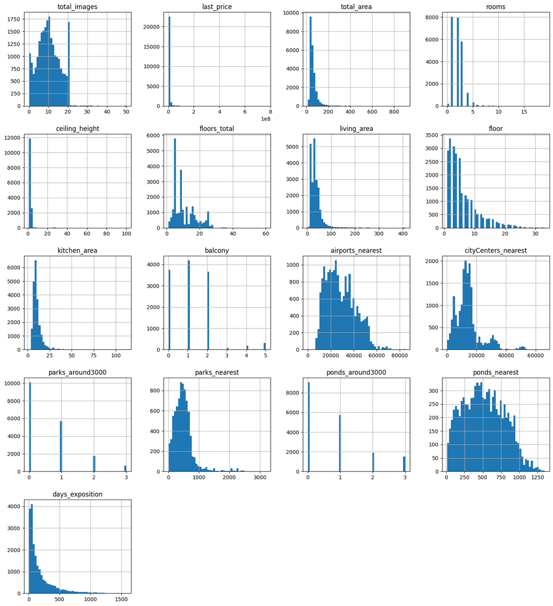

```python
data_numerical.hist(bins=50, figsize=(18, 20))
plt.show()
```

```python
print("\033[1mПроцент пропусков от всего датасета:\033[0m")
print()
formatted_output = data.isna().mean().sort_values(ascending=False).apply(lambda x: "{:.0%}".format(x))
print(formatted_output)
```

```
Процент пропусков от всего датасета:

is_apartment            88%
parks_nearest           66%
ponds_nearest           62%
balcony                 49%
ceiling_height          39%
airports_nearest        23%
cityCenters_nearest     23%
ponds_around3000        23%
parks_around3000        23%
days_exposition         13%
kitchen_area            10%
living_area              8%
floors_total             0%
locality_name            0%
total_images             0%
last_price               0%
studio                   0%
floor                    0%
rooms                    0%
first_day_exposition     0%
total_area               0%
open_plan                0%
dtype: object
```

Датафрейм состоит 23699 строк и 22 столбцов, в нем присутствуют разные типы данных т.к. (float64, int64, bool, object), имеются пропуски в столбцах, в некоторых случаях критические. Например в столбцах `is_apartment` пропущено 88 % строк.  
Столбец `cityCenters_nearest` имеет название отличное от `snake_case`.  
Некоторые столбцы имеют неправильный тип данных. Столбец `is_apartment` должен содержать значения типа `bool` вместо `object`, а `first_day_exposition` datetime.

## Выполните предобработку данных

### Приведение всех столбцов к виду snake_case

```python
# Переименнование столбца в snake_case
data = data.rename(columns={'cityCenters_nearest': 'city_centers_nearest'})
```

### Нахождение пропусков в датафрейме

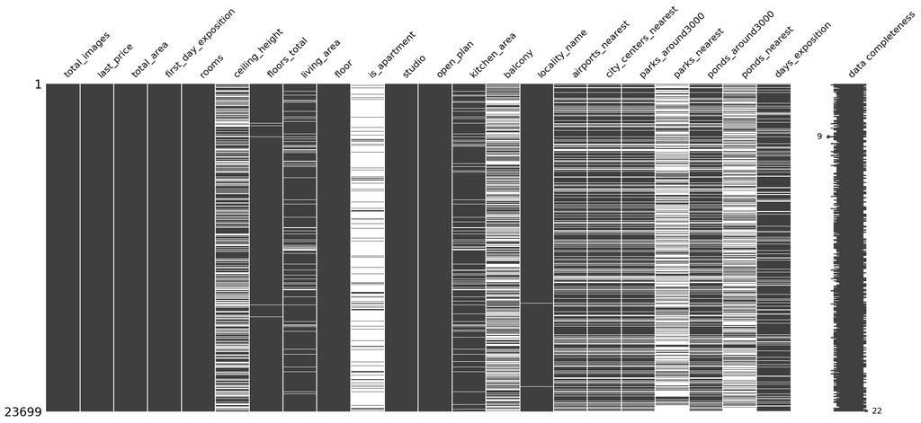

```python
msno.matrix(data, labels=True)
```

```python
data.isna().sum()
```

```
total_images                0
last_price                  0
total_area                  0
first_day_exposition        0
rooms                       0
ceiling_height           9195
floors_total               86
living_area              1903
floor                       0
is_apartment            20924
studio                      0
open_plan                   0
kitchen_area             2278
balcony                 11519
locality_name              49
airports_nearest         5542
city_centers_nearest     5519
parks_around3000         5518
parks_nearest           15620
ponds_around3000         5518
ponds_nearest           14589
days_exposition          3181
dtype: int64
```

Пропущенные значения в столбцах `locality_name` и `floors_total` имеют очень редкий характер, а также сложную логику, поэтому заполнить эти значения без дополнительной информации, например: год постройки здания для столбца количества этажей или геоданные при публикации объявления. Для улучшения качества датафрейма строки с данными пропусками лучше удалить. Это не повлияет на ощий анализ.

Пропущенные значения в столбцах `balcony` и `is_apartment` имеют человеческий и технический характер, люди при отсутствии балконов или если в объявлении на продажу выстовлялась не квартира, пропускали заполнение данного параметра. Следует сообщить разработчику, чтобы он выпустил обновление для формы, запрещающую публикацию объявления без заполнения этого пункта или добавить флажок позволяющий человеку указать что у него нет балкона или в объявлении не квартира.

Пропуски в столбцах `airports_nearest`, `city_centers_nearest`, `parks_around3000`, `parks_nearest`, `ponds_around3000` и `ponds_nearest` вызваны отсутствием геоданных при публикации объявления, т.к. эти данные были получены автоматически из геосервисов. Эти данные обладают сложной логикой и заполнить их очень сложно без знания области в которой продавался объект недвижимости. Решить эту проблему можно только со стороны рназработчика. Например при отсутствии геоданных при публикации брать последнюю геопозицию устройства с которого была произведена публикация.

### Заполнение пропусков значениями

```python
data['locality_name'].isna().sum() / len(data['locality_name']) * 100
```

```
0.20675977889362418
```

Пропусков в столбце `locality_name` менее 0.21 %. Заполнить данные пропуски не представляется возможным из-за сложной логики заполнения данных пропусков, поэтому следует их удалить

```python
data = data.dropna(subset=['locality_name'])
```

Пропуски в столбце `ceiling_height` можно заполнить медианной высотой, т.к. данный метод более устойчив к выбросам в датасете

```python
# Заполним 'ceiling_height' медианной величиной
data.loc[(data['ceiling_height'].isna()), 'ceiling_height'] = data['ceiling_height'].median()
```

Пропуски в столбце `living_area` можно заполнить медианным значением сгруппированным в зависимости от количества комнат, так будет учтено количество комнат в квартире, что поможет избежать потенциальные ошибки при заполнении, например, когда площадь комнаты в многокомнатной квартире будет неправдоподобно маленькая

```python
# Заполним 'living_area' медианной величиной в зависимости от количесвта комнат
for t in data['rooms'].unique():
    data.loc[(data['rooms'] == t) & (data['living_area'].isna()), 'living_area'] = \
    data.loc[(data['rooms'] == t), 'living_area'].median()
```

Пропуски в столбце `kitchen_area` можно заполнить медианной величиной, с учетом того что в студиях, где количество комнат равно 0, сложно определить величину кухни.

```python
# Заполним 'kitchen_area'
data.loc[((data['kitchen_area'].isna()) & (data['rooms'] > 0)), 'kitchen_area'] = data['kitchen_area'].median()
```

```python
data.loc[(data['days_exposition'].isna()), 'days_exposition'] = data['days_exposition'].median()
```

```python
# Список столбцов, которые нужно заполнить медианными значениями
columns_to_fill = [
    'airports_nearest', 'city_centers_nearest', 'parks_around3000', 'parks_nearest',
    'ponds_around3000'
                  ]

# Цикл для заполнения каждого столбца медианными значениями по группировке 'locality_name'
for column in columns_to_fill:
    median_values = data.groupby('locality_name')[column].transform('median')  # Вычисляем медиану по группе
    data[column] = data[column].fillna(median_values)  # Заполняем пропущенные значения медианой
```

```python
# Заполнение пустых строчек значением False
data['is_apartment'] = data['is_apartment'].fillna(False)
```

```python
# Заполнение пустых строчек столбца 'balcony' значением 0
data['balcony'] = data['balcony'].fillna(0)
```

```python
# Удаление пустых строчек датасета у которых floors_total == None
data = data.dropna(subset=['floors_total'])
```

```python
data.isna().sum()
```

```
total_images                0
last_price                  0
total_area                  0
first_day_exposition        0
rooms                       0
ceiling_height              0
floors_total                0
living_area                 0
floor                       0
is_apartment                0
studio                      0
open_plan                   0
kitchen_area              194
balcony                     0
locality_name               0
airports_nearest         5378
city_centers_nearest     5378
parks_around3000         5378
parks_nearest            5986
ponds_around3000         5378
ponds_nearest           14529
days_exposition             0
dtype: int64
```

При предобработке данных были заполнены пропущенные значения там, где это возможно.

### Установление корректного типа данных в датафрейме

```python
# Перевод данных принадлежит ли квартира к апартаментам из типа object к типу bool
data['is_apartment'] = data['is_apartment'].astype('bool')
```

Приведение типа данных в столбце `is_apartment` к типу bool было произведено, т.к. этот столбец имеет всего два значаения (`True`- если в объявлении продается квартира и `False`- если нет). Это экономит количество памяти занимаемое датафреймом, т.к. для сохранения такой ячейки требуется всего 2 бита памяти, по сравнению с object требующим кодировку данных в ASCII

```python
# Перевод данных из столбца 'first_day_exposition' в формат datetime округленный по дням
data['first_day_exposition'] = pd.to_datetime(data['first_day_exposition'], format = '%Y-%m-%dT%H:%M:%S').round('1D')
data.head() #проверка
```

|  | total_images | last_price | total_area | first_day_exposition | rooms | ceiling_height | floors_total | living_area | floor | is_apartment | ... | kitchen_area | balcony | locality_name | airports_nearest | city_centers_nearest | parks_around3000 | parks_nearest | ponds_around3000 | ponds_nearest | days_exposition |
| --- | --- | --- | --- | --- | --- | --- | --- | --- | --- | --- | --- | --- | --- | --- | --- | --- | --- | --- | --- | --- | --- |
| 0 | 20 | 13000000.0 | 108.0 | 2019-03-07 | 3 | 2.70 | 16.0 | 51.0 | 8 | False | ... | 25.0 | 0.0 | Санкт-Петербург | 18863.0 | 16028.0 | 1.0 | 482.0 | 2.0 | 755.0 | 95.0 |
| 1 | 7 | 3350000.0 | 40.4 | 2018-12-04 | 1 | 2.65 | 11.0 | 18.6 | 1 | False | ... | 11.0 | 2.0 | посёлок Шушары | 12817.0 | 18603.0 | 0.0 | NaN | 0.0 | NaN | 81.0 |
| 2 | 10 | 5196000.0 | 56.0 | 2015-08-20 | 2 | 2.65 | 5.0 | 34.3 | 4 | False | ... | 8.3 | 0.0 | Санкт-Петербург | 21741.0 | 13933.0 | 1.0 | 90.0 | 2.0 | 574.0 | 558.0 |
| 3 | 0 | 64900000.0 | 159.0 | 2015-07-24 | 3 | 2.65 | 14.0 | 45.0 | 9 | False | ... | 9.1 | 0.0 | Санкт-Петербург | 28098.0 | 6800.0 | 2.0 | 84.0 | 3.0 | 234.0 | 424.0 |
| 4 | 2 | 10000000.0 | 100.0 | 2018-06-19 | 2 | 3.03 | 14.0 | 32.0 | 13 | False | ... | 41.0 | 0.0 | Санкт-Петербург | 31856.0 | 8098.0 | 2.0 | 112.0 | 1.0 | 48.0 | 121.0 |

5 rows × 22 columns

### Избавление датафрейма от дубликатов

```python
data.duplicated().sum()
```

```
0
```

В датафрейме отсутствуют явные дубликаты, поэтому остается проверить датафрейм на неявные дубликаты. Чаще всего проблемы возникают в столбцах с типом данных `object`. В нашем датафрейме - это столбец `locality_name`, по нему и будем производить поиск.

```python
set(data['locality_name'])
```

```
{'Бокситогорск',
 'Волосово',
 'Волхов',
 'Всеволожск',
 'Выборг',
 'Высоцк',
 'Гатчина',
 'Зеленогорск',
 'Ивангород',
 'Каменногорск',
 'Кингисепп',
 'Кириши',
 'Кировск',
 'Колпино',
 'Коммунар',
 'Красное Село',
 'Кронштадт',
 'Кудрово',
 'Лодейное Поле',
 'Ломоносов',
 'Луга',
 'Любань',
 'Мурино',
 'Никольское',
 'Новая Ладога',
 'Отрадное',
 'Павловск',
 'Петергоф',
 'Пикалёво',
 'Подпорожье',
 'Приморск',
 'Приозерск',
 'Пушкин',
 'Санкт-Петербург',
 'Светогорск',
 'Сертолово',
 'Сестрорецк',
 'Сланцы',
 'Сосновый Бор',
 'Сясьстрой',
```

[output cut: 309 more lines]

```
 'посёлок станции Свирь',
 'садоводческое некоммерческое товарищество Лесная Поляна',
 'садовое товарищество Новая Ропша',
 'садовое товарищество Приладожский',
 'садовое товарищество Рахья',
 'садовое товарищество Садко',
 'село Копорье',
 'село Никольское',
 'село Павлово',
 'село Паша',
 'село Путилово',
 'село Рождествено',
 'село Русско-Высоцкое',
 'село Старая Ладога',
 'село Шум'}
```

```python
len(set(data['locality_name']))
```

```
364
```

Были замечены следующие неявные дубликаты в столбце - «поселок Рябово» и «поселок городского типа Рябово», «поселок Тельмана» и «посёлок Тельмана» и т.д. Решить данную проблему возможно заменой всех букв ё на е, и приведение всех названий поселков к типу поселок.

```python
data['locality_name'] = (
    data['locality_name']
    .str.replace('ё', 'е')
    .replace(['поселок городского типа', 'городской поселок'], 'поселок', regex=True)
)
```

```python
# Проверка
set(data['locality_name'])
```

```
{'Бокситогорск',
 'Волосово',
 'Волхов',
 'Всеволожск',
 'Выборг',
 'Высоцк',
 'Гатчина',
 'Зеленогорск',
 'Ивангород',
 'Каменногорск',
 'Кингисепп',
 'Кириши',
 'Кировск',
 'Колпино',
 'Коммунар',
 'Красное Село',
 'Кронштадт',
 'Кудрово',
 'Лодейное Поле',
 'Ломоносов',
 'Луга',
 'Любань',
 'Мурино',
 'Никольское',
 'Новая Ладога',
 'Отрадное',
 'Павловск',
 'Петергоф',
 'Пикалево',
 'Подпорожье',
 'Приморск',
 'Приозерск',
 'Пушкин',
 'Санкт-Петербург',
 'Светогорск',
 'Сертолово',
 'Сестрорецк',
 'Сланцы',
 'Сосновый Бор',
 'Сясьстрой',
```

[output cut: 267 more lines]

```
 'поселок станции Свирь',
 'садоводческое некоммерческое товарищество Лесная Поляна',
 'садовое товарищество Новая Ропша',
 'садовое товарищество Приладожский',
 'садовое товарищество Рахья',
 'садовое товарищество Садко',
 'село Копорье',
 'село Никольское',
 'село Павлово',
 'село Паша',
 'село Путилово',
 'село Рождествено',
 'село Русско-Высоцкое',
 'село Старая Ладога',
 'село Шум'}
```

```python
len(set(data['locality_name']))
```

```
322
```

```python
data.duplicated().sum()
```

```
0
```

Выполнена обработка неявных дубликатов в датафрейме, в результате этой проверки количество уникальных имен в столбце `locality_name` уменьшилось с 364 до 322, это позволило убрать неявные дубликаты в датасте, что улучшит качество дальнейшего анализа.

### Обработка анамальных значений (выбросов) в датафрейме

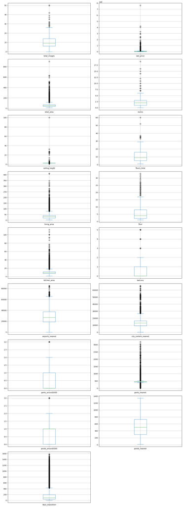

```python
data.select_dtypes(include=['float64', 'int64']).plot(
    kind='box', subplots=True, layout=(len(data.columns)//2, 2), figsize=(15, 50), sharex=False, sharey=False, grid=True
)
plt.title("Графики для нахождения выбросов в датафрейме")
plt.tight_layout()
plt.show()
```

```python
def count_outliers(df):
    outliers = {}
    for column in df.select_dtypes(include=['float64', 'int64']):  # Обрабатываем только числовые столбцы
        Q1 = df[column].quantile(0.25)
        Q3 = df[column].quantile(0.75)
        IQR = Q3 - Q1
        lower_bound = Q1 - 1.5 * IQR
        upper_bound = Q3 + 1.5 * IQR
        outliers[column] = ((df[column] < lower_bound) | (df[column] > upper_bound)).sum()
    return outliers

# Подсчет выбросов
outliers_count = count_outliers(data)
print(outliers_count)
```

```
{'total_images': 25, 'last_price': 2046, 'total_area': 1239, 'rooms': 90, 'ceiling_height': 2949, 'floors_total': 32, 'living_area': 777, 'floor': 902, 'kitchen_area': 1511, 'balcony': 567, 'airports_nearest': 101, 'city_centers_nearest': 1750, 'parks_around3000': 643, 'parks_nearest': 6864, 'ponds_…
```

```python
set(data['ceiling_height'])
```

```
{1.0,
 1.2,
 1.75,
 2.0,
 2.2,
 2.25,
 2.3,
 2.34,
 2.4,
 2.45,
 2.46,
 2.47,
 2.48,
 2.49,
 2.5,
 2.51,
 2.52,
 2.53,
 2.54,
 2.55,
 2.56,
 2.57,
 2.58,
 2.59,
 2.6,
 2.61,
 2.62,
 2.63,
 2.64,
 2.65,
 2.66,
 2.67,
 2.68,
 2.69,
 2.7,
 2.71,
 2.72,
 2.73,
 2.74,
 2.75,
```

[output cut: 128 more lines]

```
 5.8,
 6.0,
 8.0,
 8.3,
 10.3,
 14.0,
 20.0,
 22.6,
 24.0,
 25.0,
 26.0,
 27.0,
 27.5,
 32.0,
 100.0}
```

В столбце `ceiling_height` встречаются значения от 22.6 до 32. Вероятная причина таких анамальных значений - потеря запятой. Решим данную проблему.

```python
rows = (data['ceiling_height'] / 10 >= 2.25) & (data['ceiling_height'] / 10 <= 3.2)
data.loc[rows, 'ceiling_height'] = data['ceiling_height'] / 10
data['ceiling_height'] = data['ceiling_height'].round(2) # Округление до 2 знака
```

```python
set(data['ceiling_height']) # Проверка
```

```
{1.0,
 1.2,
 1.75,
 2.0,
 2.2,
 2.25,
 2.26,
 2.3,
 2.34,
 2.4,
 2.45,
 2.46,
 2.47,
 2.48,
 2.49,
 2.5,
 2.51,
 2.52,
 2.53,
 2.54,
 2.55,
 2.56,
 2.57,
 2.58,
 2.59,
 2.6,
 2.61,
 2.62,
 2.63,
 2.64,
 2.65,
 2.66,
 2.67,
 2.68,
 2.69,
 2.7,
 2.71,
 2.72,
 2.73,
 2.74,
```

[output cut: 122 more lines]

```
 4.8,
 4.9,
 5.0,
 5.2,
 5.3,
 5.5,
 5.6,
 5.8,
 6.0,
 8.0,
 8.3,
 10.3,
 14.0,
 20.0,
 100.0}
```

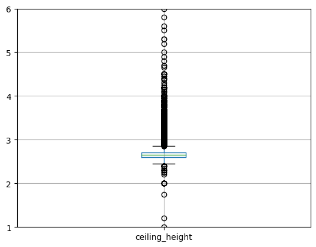

```python
plt.ylim(1, 6)
data.boxplot(column='ceiling_height')
```

```python
ceiling_height_too_high = data.query('ceiling_height > 3.2')
display(ceiling_height_too_high.shape[0])
ceiling_height_too_low = data.query('ceiling_height < 2.25')
display(ceiling_height_too_low.shape[0] + ceiling_height_too_high.shape[0])
(ceiling_height_too_low.shape[0] + ceiling_height_too_high.shape[0]) / data['ceiling_height'].shape[0] * 100
```

```
794
```

```
809
```

```
3.4330575005304476
```

```python
# Отбрасываем выбросы данных, которые не попадают в  интервал 2.25 < ceiling_height < 3.2
data = data.query('ceiling_height <= 3.2 and ceiling_height >= 2.25')
data['ceiling_height'].shape[0]
```

```
22756
```

```python
# Функция для удаления выбросов в выбранных столбцах
def remove_outliers(df, columns):
    for column in columns:
        Q1 = df[column].quantile(0.25)
        Q3 = df[column].quantile(0.75)
        IQR = Q3 - Q1
        lower_bound = Q1 - 1.5 * IQR
        upper_bound = Q3 + 1.5 * IQR

        # Фильтруем строки, где значения в пределах границ
        df = df[(df[column] >= lower_bound) & (df[column] <= upper_bound)]

    return df

# Удаляем выбросы только в указанных столбцах
columns_filter = [
    'balcony', 'rooms', 'kitchen_area',
    'total_area', 'living_area'
]
data_clean = remove_outliers(data, columns_filter)
```

```python
display(data_clean.shape)
print(round((data.shape[0] - data_clean.shape[0]) / data.shape[0] * 100))
```

```
(19805, 22)
```

```
13
```

В ходе обработки анамальных значений в датафрейме, были обнаружены выбросы, их общая сумма 13%. Эти выбросы сильно не влияют на анализ, а их удаление, может повлиять на общий анализ.  
Выбросы в столбцах `rooms`, `kitchen_area`, `total_area`, `living_area` связаны с тем, что квартиры с большими площадями встречаются очень редко, но при удалении этих данных может потеряться информация об элитном жилье, а проведенный анализ будет неполным.

## Добавление в таблицу новых столбцов

```python
# Добавление столбца с описанием этажа
def floor_type(row):
    '''
    Возвращает тип этажа по следующему правилу:
    * этаж == 1 - 'первый';
    * этаж == data['floors_total'] - 'последний';
    * во всех остальных случаях - 'другой'.
    '''
    if row['floor'] == 1:
        return 'первый'
    if row['floor'] == row['floors_total']:
        return 'последний'
    return 'другой'
data['floor_type'] = data.apply(floor_type, axis=1) #Применение функции
data.head() #Проверка
```

|  | total_images | last_price | total_area | first_day_exposition | rooms | ceiling_height | floors_total | living_area | floor | is_apartment | ... | balcony | locality_name | airports_nearest | city_centers_nearest | parks_around3000 | parks_nearest | ponds_around3000 | ponds_nearest | days_exposition | floor_type |
| --- | --- | --- | --- | --- | --- | --- | --- | --- | --- | --- | --- | --- | --- | --- | --- | --- | --- | --- | --- | --- | --- |
| 0 | 20 | 13000000.0 | 108.0 | 2019-03-07 | 3 | 2.70 | 16.0 | 51.0 | 8 | False | ... | 0.0 | Санкт-Петербург | 18863.0 | 16028.0 | 1.0 | 482.0 | 2.0 | 755.0 | 95.0 | другой |
| 1 | 7 | 3350000.0 | 40.4 | 2018-12-04 | 1 | 2.65 | 11.0 | 18.6 | 1 | False | ... | 2.0 | поселок Шушары | 12817.0 | 18603.0 | 0.0 | NaN | 0.0 | NaN | 81.0 | первый |
| 2 | 10 | 5196000.0 | 56.0 | 2015-08-20 | 2 | 2.65 | 5.0 | 34.3 | 4 | False | ... | 0.0 | Санкт-Петербург | 21741.0 | 13933.0 | 1.0 | 90.0 | 2.0 | 574.0 | 558.0 | другой |
| 3 | 0 | 64900000.0 | 159.0 | 2015-07-24 | 3 | 2.65 | 14.0 | 45.0 | 9 | False | ... | 0.0 | Санкт-Петербург | 28098.0 | 6800.0 | 2.0 | 84.0 | 3.0 | 234.0 | 424.0 | другой |
| 4 | 2 | 10000000.0 | 100.0 | 2018-06-19 | 2 | 3.03 | 14.0 | 32.0 | 13 | False | ... | 0.0 | Санкт-Петербург | 31856.0 | 8098.0 | 2.0 | 112.0 | 1.0 | 48.0 | 121.0 | другой |

5 rows × 23 columns

```python
# Добавление столбца цены за 1 кв. метр
data['price_per_meter'] = data['last_price'] / data['total_area']
data.head()
```

|  | total_images | last_price | total_area | first_day_exposition | rooms | ceiling_height | floors_total | living_area | floor | is_apartment | ... | locality_name | airports_nearest | city_centers_nearest | parks_around3000 | parks_nearest | ponds_around3000 | ponds_nearest | days_exposition | floor_type | price_per_meter |
| --- | --- | --- | --- | --- | --- | --- | --- | --- | --- | --- | --- | --- | --- | --- | --- | --- | --- | --- | --- | --- | --- |
| 0 | 20 | 13000000.0 | 108.0 | 2019-03-07 | 3 | 2.70 | 16.0 | 51.0 | 8 | False | ... | Санкт-Петербург | 18863.0 | 16028.0 | 1.0 | 482.0 | 2.0 | 755.0 | 95.0 | другой | 120370.370370 |
| 1 | 7 | 3350000.0 | 40.4 | 2018-12-04 | 1 | 2.65 | 11.0 | 18.6 | 1 | False | ... | поселок Шушары | 12817.0 | 18603.0 | 0.0 | NaN | 0.0 | NaN | 81.0 | первый | 82920.792079 |
| 2 | 10 | 5196000.0 | 56.0 | 2015-08-20 | 2 | 2.65 | 5.0 | 34.3 | 4 | False | ... | Санкт-Петербург | 21741.0 | 13933.0 | 1.0 | 90.0 | 2.0 | 574.0 | 558.0 | другой | 92785.714286 |
| 3 | 0 | 64900000.0 | 159.0 | 2015-07-24 | 3 | 2.65 | 14.0 | 45.0 | 9 | False | ... | Санкт-Петербург | 28098.0 | 6800.0 | 2.0 | 84.0 | 3.0 | 234.0 | 424.0 | другой | 408176.100629 |
| 4 | 2 | 10000000.0 | 100.0 | 2018-06-19 | 2 | 3.03 | 14.0 | 32.0 | 13 | False | ... | Санкт-Петербург | 31856.0 | 8098.0 | 2.0 | 112.0 | 1.0 | 48.0 | 121.0 | другой | 100000.000000 |

5 rows × 24 columns

Добавление новых столбцов в датафрейм: день недели - `day_of_publication`, месяц - `month_of_publication` и год публикации объявления - `year_of_publication`

```python
data['day_of_publication'] = data['first_day_exposition'].dt.day_name(locale='Russian')
data['month_of_publication'] = data['first_day_exposition'].dt.month_name(locale='Russian')
data['year_of_publication'] = data['first_day_exposition'].dt.year
data.head(20) # Проверка
```

|  | total_images | last_price | total_area | first_day_exposition | rooms | ceiling_height | floors_total | living_area | floor | is_apartment | ... | parks_around3000 | parks_nearest | ponds_around3000 | ponds_nearest | days_exposition | floor_type | price_per_meter | day_of_publication | month_of_publication | year_of_publication |
| --- | --- | --- | --- | --- | --- | --- | --- | --- | --- | --- | --- | --- | --- | --- | --- | --- | --- | --- | --- | --- | --- |
| 0 | 20 | 13000000.0 | 108.00 | 2019-03-07 | 3 | 2.70 | 16.0 | 51.00 | 8 | False | ... | 1.0 | 482.0 | 2.0 | 755.0 | 95.0 | другой | 120370.370370 | Четверг | Март | 2019 |
| 1 | 7 | 3350000.0 | 40.40 | 2018-12-04 | 1 | 2.65 | 11.0 | 18.60 | 1 | False | ... | 0.0 | NaN | 0.0 | NaN | 81.0 | первый | 82920.792079 | Вторник | Декабрь | 2018 |
| 2 | 10 | 5196000.0 | 56.00 | 2015-08-20 | 2 | 2.65 | 5.0 | 34.30 | 4 | False | ... | 1.0 | 90.0 | 2.0 | 574.0 | 558.0 | другой | 92785.714286 | Четверг | Август | 2015 |
| 3 | 0 | 64900000.0 | 159.00 | 2015-07-24 | 3 | 2.65 | 14.0 | 45.00 | 9 | False | ... | 2.0 | 84.0 | 3.0 | 234.0 | 424.0 | другой | 408176.100629 | Пятница | Июль | 2015 |
| 4 | 2 | 10000000.0 | 100.00 | 2018-06-19 | 2 | 3.03 | 14.0 | 32.00 | 13 | False | ... | 2.0 | 112.0 | 1.0 | 48.0 | 121.0 | другой | 100000.000000 | Вторник | Июнь | 2018 |
| 5 | 10 | 2890000.0 | 30.40 | 2018-09-10 | 1 | 2.65 | 12.0 | 14.40 | 5 | False | ... | NaN | NaN | NaN | NaN | 55.0 | другой | 95065.789474 | Понедельник | Сентябрь | 2018 |
| 6 | 6 | 3700000.0 | 37.30 | 2017-11-02 | 1 | 2.65 | 26.0 | 10.60 | 6 | False | ... | 0.0 | 733.0 | 0.0 | NaN | 155.0 | другой | 99195.710456 | Четверг | Ноябрь | 2017 |
| 7 | 5 | 7915000.0 | 71.60 | 2019-04-18 | 2 | 2.65 | 24.0 | 30.50 | 22 | False | ... | 0.0 | 460.0 | 0.0 | NaN | 95.0 | другой | 110544.692737 | Четверг | Апрель | 2019 |
| 8 | 20 | 2900000.0 | 33.16 | 2018-05-23 | 1 | 2.65 | 27.0 | 15.43 | 26 | False | ... | NaN | NaN | NaN | NaN | 189.0 | другой | 87454.764777 | Среда | Май | 2018 |
| 9 | 18 | 5400000.0 | 61.00 | 2017-02-26 | 3 | 2.50 | 9.0 | 43.60 | 7 | False | ... | 0.0 | 460.0 | 0.0 | NaN | 289.0 | другой | 88524.590164 | Воскресенье | Февраль | 2017 |
| 10 | 5 | 5050000.0 | 39.60 | 2017-11-16 | 1 | 2.67 | 12.0 | 20.30 | 3 | False | ... | 1.0 | 310.0 | 2.0 | 553.0 | 137.0 | другой | 127525.252525 | Четверг | Ноябрь | 2017 |
| 11 | 9 | 3300000.0 | 44.00 | 2018-08-27 | 2 | 2.65 | 5.0 | 31.00 | 4 | False | ... | 0.0 | 407.0 | 0.0 | NaN | 7.0 | другой | 75000.000000 | Понедельник | Август | 2018 |
| 12 | 10 | 3890000.0 | 54.00 | 2016-06-30 | 2 | 2.65 | 5.0 | 30.00 | 5 | False | ... | NaN | NaN | NaN | NaN | 90.0 | последний | 72037.037037 | Четверг | Июнь | 2016 |
| 13 | 20 | 3550000.0 | 42.80 | 2017-07-01 | 2 | 2.56 | 5.0 | 27.00 | 5 | False | ... | 1.0 | 294.0 | 3.0 | 298.0 | 366.0 | последний | 82943.925234 | Суббота | Июль | 2017 |
| 14 | 1 | 4400000.0 | 36.00 | 2016-06-23 | 1 | 2.65 | 6.0 | 17.00 | 1 | False | ... | 0.0 | 399.5 | 1.0 | 96.0 | 203.0 | первый | 122222.222222 | Четверг | Июнь | 2016 |
| 15 | 16 | 4650000.0 | 39.00 | 2017-11-18 | 1 | 2.65 | 14.0 | 20.50 | 5 | False | ... | 1.0 | 590.0 | 1.0 | 296.0 | 19.0 | другой | 119230.769231 | Суббота | Ноябрь | 2017 |
| 16 | 11 | 6700000.0 | 82.00 | 2017-11-23 | 3 | 3.05 | 5.0 | 55.60 | 1 | False | ... | 3.0 | 420.0 | 0.0 | NaN | 397.0 | первый | 81707.317073 | Четверг | Ноябрь | 2017 |
| 17 | 6 | 4180000.0 | 36.00 | 2016-09-09 | 1 | 2.65 | 17.0 | 16.50 | 7 | False | ... | 0.0 | 460.0 | 1.0 | 859.0 | 571.0 | другой | 116111.111111 | Пятница | Сентябрь | 2016 |
| 18 | 8 | 3250000.0 | 31.00 | 2017-01-27 | 1 | 2.50 | 5.0 | 19.40 | 2 | False | ... | 1.0 | 759.0 | 0.0 | NaN | 168.0 | другой | 104838.709677 | Пятница | Январь | 2017 |
| 19 | 16 | 14200000.0 | 121.00 | 2019-01-09 | 3 | 2.75 | 16.0 | 76.00 | 8 | False | ... | 0.0 | 460.0 | 0.0 | NaN | 97.0 | другой | 117355.371901 | Среда | Январь | 2019 |

20 rows × 27 columns

Добавление в датафрейм столбца `city_centers_nearest_km` с расстоянием до центра города в километрах (округлено до целых)

```python
data = data.assign(city_centers_nearest_km = lambda x: (round(x['city_centers_nearest'] / 1000)))
data.head(20)
```

|  | total_images | last_price | total_area | first_day_exposition | rooms | ceiling_height | floors_total | living_area | floor | is_apartment | ... | parks_nearest | ponds_around3000 | ponds_nearest | days_exposition | floor_type | price_per_meter | day_of_publication | month_of_publication | year_of_publication | city_centers_nearest_km |
| --- | --- | --- | --- | --- | --- | --- | --- | --- | --- | --- | --- | --- | --- | --- | --- | --- | --- | --- | --- | --- | --- |
| 0 | 20 | 13000000.0 | 108.00 | 2019-03-07 | 3 | 2.70 | 16.0 | 51.00 | 8 | False | ... | 482.0 | 2.0 | 755.0 | 95.0 | другой | 120370.370370 | Четверг | Март | 2019 | 16.0 |
| 1 | 7 | 3350000.0 | 40.40 | 2018-12-04 | 1 | 2.65 | 11.0 | 18.60 | 1 | False | ... | NaN | 0.0 | NaN | 81.0 | первый | 82920.792079 | Вторник | Декабрь | 2018 | 19.0 |
| 2 | 10 | 5196000.0 | 56.00 | 2015-08-20 | 2 | 2.65 | 5.0 | 34.30 | 4 | False | ... | 90.0 | 2.0 | 574.0 | 558.0 | другой | 92785.714286 | Четверг | Август | 2015 | 14.0 |
| 3 | 0 | 64900000.0 | 159.00 | 2015-07-24 | 3 | 2.65 | 14.0 | 45.00 | 9 | False | ... | 84.0 | 3.0 | 234.0 | 424.0 | другой | 408176.100629 | Пятница | Июль | 2015 | 7.0 |
| 4 | 2 | 10000000.0 | 100.00 | 2018-06-19 | 2 | 3.03 | 14.0 | 32.00 | 13 | False | ... | 112.0 | 1.0 | 48.0 | 121.0 | другой | 100000.000000 | Вторник | Июнь | 2018 | 8.0 |
| 5 | 10 | 2890000.0 | 30.40 | 2018-09-10 | 1 | 2.65 | 12.0 | 14.40 | 5 | False | ... | NaN | NaN | NaN | 55.0 | другой | 95065.789474 | Понедельник | Сентябрь | 2018 | NaN |
| 6 | 6 | 3700000.0 | 37.30 | 2017-11-02 | 1 | 2.65 | 26.0 | 10.60 | 6 | False | ... | 733.0 | 0.0 | NaN | 155.0 | другой | 99195.710456 | Четверг | Ноябрь | 2017 | 19.0 |
| 7 | 5 | 7915000.0 | 71.60 | 2019-04-18 | 2 | 2.65 | 24.0 | 30.50 | 22 | False | ... | 460.0 | 0.0 | NaN | 95.0 | другой | 110544.692737 | Четверг | Апрель | 2019 | 12.0 |
| 8 | 20 | 2900000.0 | 33.16 | 2018-05-23 | 1 | 2.65 | 27.0 | 15.43 | 26 | False | ... | NaN | NaN | NaN | 189.0 | другой | 87454.764777 | Среда | Май | 2018 | NaN |
| 9 | 18 | 5400000.0 | 61.00 | 2017-02-26 | 3 | 2.50 | 9.0 | 43.60 | 7 | False | ... | 460.0 | 0.0 | NaN | 289.0 | другой | 88524.590164 | Воскресенье | Февраль | 2017 | 15.0 |
| 10 | 5 | 5050000.0 | 39.60 | 2017-11-16 | 1 | 2.67 | 12.0 | 20.30 | 3 | False | ... | 310.0 | 2.0 | 553.0 | 137.0 | другой | 127525.252525 | Четверг | Ноябрь | 2017 | 14.0 |
| 11 | 9 | 3300000.0 | 44.00 | 2018-08-27 | 2 | 2.65 | 5.0 | 31.00 | 4 | False | ... | 407.0 | 0.0 | NaN | 7.0 | другой | 75000.000000 | Понедельник | Август | 2018 | 52.0 |
| 12 | 10 | 3890000.0 | 54.00 | 2016-06-30 | 2 | 2.65 | 5.0 | 30.00 | 5 | False | ... | NaN | NaN | NaN | 90.0 | последний | 72037.037037 | Четверг | Июнь | 2016 | NaN |
| 13 | 20 | 3550000.0 | 42.80 | 2017-07-01 | 2 | 2.56 | 5.0 | 27.00 | 5 | False | ... | 294.0 | 3.0 | 298.0 | 366.0 | последний | 82943.925234 | Суббота | Июль | 2017 | 33.0 |
| 14 | 1 | 4400000.0 | 36.00 | 2016-06-23 | 1 | 2.65 | 6.0 | 17.00 | 1 | False | ... | 399.5 | 1.0 | 96.0 | 203.0 | первый | 122222.222222 | Четверг | Июнь | 2016 | 31.0 |
| 15 | 16 | 4650000.0 | 39.00 | 2017-11-18 | 1 | 2.65 | 14.0 | 20.50 | 5 | False | ... | 590.0 | 1.0 | 296.0 | 19.0 | другой | 119230.769231 | Суббота | Ноябрь | 2017 | 14.0 |
| 16 | 11 | 6700000.0 | 82.00 | 2017-11-23 | 3 | 3.05 | 5.0 | 55.60 | 1 | False | ... | 420.0 | 0.0 | NaN | 397.0 | первый | 81707.317073 | Четверг | Ноябрь | 2017 | 11.0 |
| 17 | 6 | 4180000.0 | 36.00 | 2016-09-09 | 1 | 2.65 | 17.0 | 16.50 | 7 | False | ... | 460.0 | 1.0 | 859.0 | 571.0 | другой | 116111.111111 | Пятница | Сентябрь | 2016 | 15.0 |
| 18 | 8 | 3250000.0 | 31.00 | 2017-01-27 | 1 | 2.50 | 5.0 | 19.40 | 2 | False | ... | 759.0 | 0.0 | NaN | 168.0 | другой | 104838.709677 | Пятница | Январь | 2017 | 11.0 |
| 19 | 16 | 14200000.0 | 121.00 | 2019-01-09 | 3 | 2.75 | 16.0 | 76.00 | 8 | False | ... | 460.0 | 0.0 | NaN | 97.0 | другой | 117355.371901 | Среда | Январь | 2019 | 13.0 |

20 rows × 28 columns

## Проведение исследовательского анализа данных

### Иследование параметров

- общая площадь;
- жилая площадь;
- площадь кухни;
- цена объекта;
- количество комнат;
- высота потолков;
- тип этажа квартиры («первый», «последний», «другой»);
- общее количество этажей в доме;
- расстояние до центра города в метрах;
- расстояние до ближайшего парка

```
count    22756.000000
mean        58.383482
std         31.667716
min         12.000000
25%         40.000000
50%         51.000000
75%         67.717500
max        900.000000
Name: total_area, dtype: float64
```

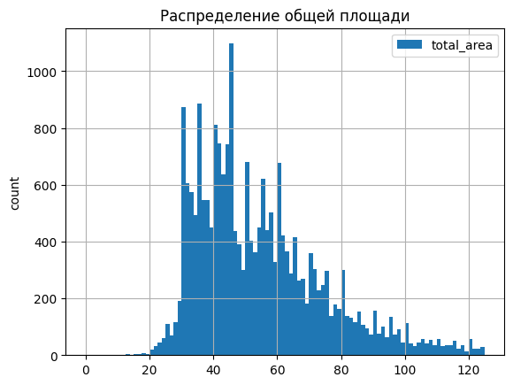

```python
data.plot(
    y='total_area',
    kind='hist',
    grid=True,
    bins=100,
    range=(0, 125),
    ylabel='count',
    title="Распределение общей площади"
)
data['total_area'].describe()
```

- Среднее значение общей площади 58 $м^{2}$;
- Медианное значение общей площади 51 $м^{2}$, отличие вызвано наличием выбросов в данных, например площадь равная 900 $м^{2}$;
- Значения более 200 $м^{2}$ встречаются очень редко, чаще всего такая большая площадь недвижимости относиться к элитной;
- Распределение общей площади отличается от нормального;
- Является остроконечным;
- Распределение общей площади имеет форму Пуассона, имеет заметную положительную асимметрию.

```
count    22756.000000
mean        33.082365
std         19.023222
min          2.000000
25%         18.200000
50%         30.000000
75%         42.000000
max        409.700000
Name: living_area, dtype: float64
```

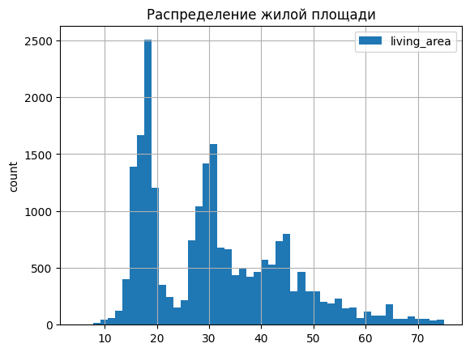

```python
data.plot(
    y='living_area',
    kind='hist',
    grid=True,
    bins=50,
    range=(5, 75),
    ylabel='count',
    title="Распределение жилой площади"
)
data['living_area'].describe()
```

[output not shown]

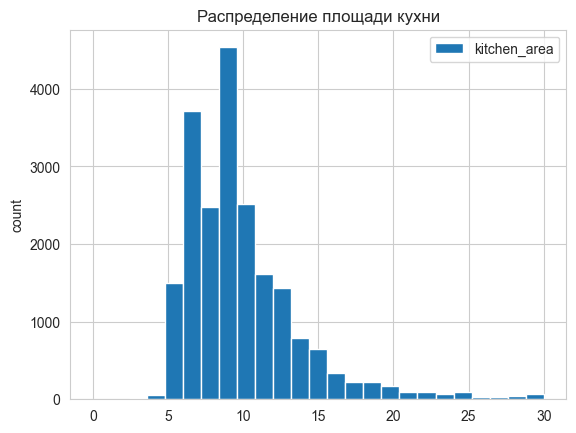

```python
data.plot(
    y='kitchen_area',
    kind='hist',
    grid=True,
    bins=25,
    range=(0, 30),
    ylabel='count',
    title="Распределение площади кухни"
)
data['kitchen_area'].describe()
```

- Среднее значение площади кухни 10 $м^{2}$;
- Медианное значение жилой площади 9 $м^{2}$, малое отличие среднего и медианного значения связано с малым средним отклонением ~ 5.2 $м^{2}$;

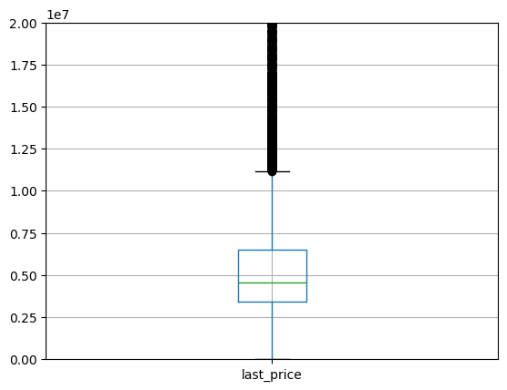

```python
plt.ylim(0, 2e+07)
data.boxplot(column='last_price')
```

```
count    2.275600e+04
mean     6.092548e+06
std      9.248961e+06
min      1.219000e+04
25%      3.400000e+06
50%      4.550000e+06
75%      6.500000e+06
max      7.630000e+08
Name: last_price, dtype: float64
```

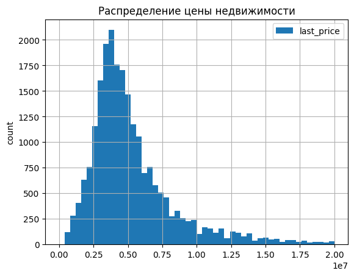

```python
data.plot(
    y='last_price',
    kind='hist',
    grid=True,
    bins=50,
    range=(1e+04, 2e+07),
    ylabel='count',
    title="Распределение цены недвижимости"
)
data['last_price'].describe()
```

```
count    21189.000000
mean         2.011987
std          1.012872
min          0.000000
25%          1.000000
50%          2.000000
75%          3.000000
max         19.000000
Name: rooms, dtype: float64
```

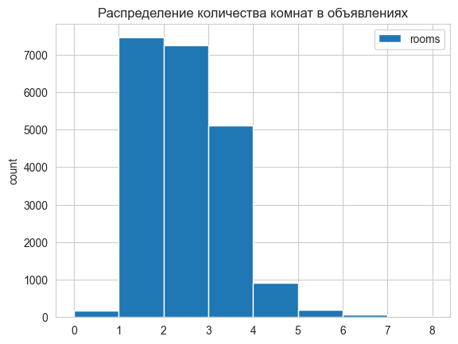

```python
data.plot(
    y='rooms',
    kind='hist',
    grid=True,
    bins=8,
    range=(0, 8),
    ylabel='count',
    title="Распределение количества комнат в объявлениях"
)
data['rooms'].describe()
```

Среднее количество комнат в выборке равно 2, медианное количество комнат в выборке тоже равно 2, хотя однакомнатных объектов немного больше, чем двухкомнатных. На такой вывод влияет тот факт, что количество аппартаментов (где количество комнат равно 0) в выборке меньше, чем многокомнатных квартир (комнат >= 3).

```
count    22756.000000
mean         2.667817
std          0.143298
min          2.250000
25%          2.600000
50%          2.650000
75%          2.700000
max          3.200000
Name: ceiling_height, dtype: float64
```

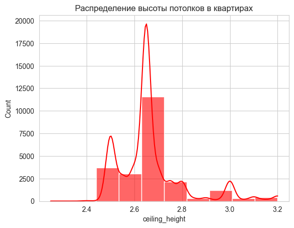

```python
sns.set_style('whitegrid')
sns.histplot(data=data,
             x='ceiling_height',
             color="red",
             alpha=0.6,
             kde=True,
             stat='count',
             bins=10,
            )
plt.title("Распределение высоты потолков в квартирах")
data['ceiling_height'].describe()
```

- Средняя высота потолков в выборке равна 2.66 м;
- Медианная высота равна 2.65 м;
- Распределение высоты потолков является Гауссовким (нормальным).

```
count    21189.000000
mean        10.877861
std          6.630424
min          1.000000
25%          5.000000
50%          9.000000
75%         16.000000
max         60.000000
Name: floors_total, dtype: float64
```

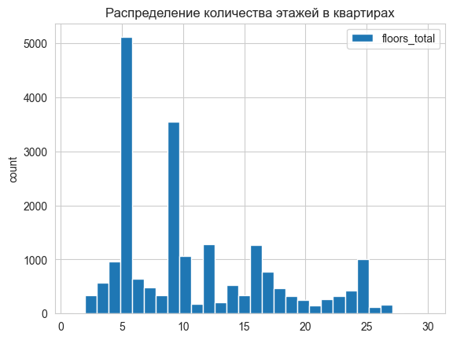

```python
data.plot(y='floors_total',
          kind='hist',
          grid=True,
          bins=30,
          range=(1, 30),
          ylabel='count',
          title="Распределение количества этажей в квартирах"
         )
data['floors_total'].describe()
```

- Среднее количество этажей здания в объявлении 11;
- Медиана равна 9;
- Чаще всего вы можете увидеть 5-ти этажные здания, чуть реже 9-ти.

```
count    17410.000000
mean     14598.975704
std       8514.522891
min        318.000000
25%       9974.250000
50%      13300.000000
75%      16478.000000
max      65968.000000
Name: city_centers_nearest, dtype: float64
```

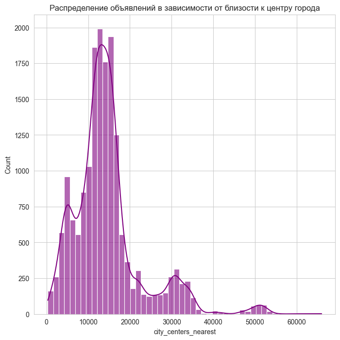

```python
plt.figure(figsize=(8, 8))
sns.histplot(data=data, x='city_centers_nearest', color="purple", alpha=0.6, kde=True, stat='count', bins=50)
plt.title("Распределение объявлений в зависимости от близости к центру города")
data['city_centers_nearest'].describe()
```

- Среднее значение расстояния от центра ~ 14500 м;
- Медианное значение расстояния от центра ~ 13300 м;
- 3/4 значений расстояний до 16500 м;
- Распределение расстояние от центра имеет форму Пуассона.

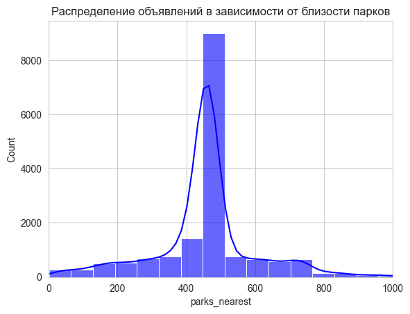

```
count    16806.000000
mean       477.421248
std        234.381465
min          1.000000
25%        431.000000
50%        460.000000
75%        460.000000
max       3190.000000
Name: parks_nearest, dtype: float64
```

```python
z = sns.histplot(data=data, x='parks_nearest', color="blue", alpha=0.6, kde=True, stat='count', bins=50)
plt.figure(figsize=(8, 8))
z.set_title("Распределение объявлений в зависимости от близости парков")
z.set(xlim=(0, 1000))
plt.show()
data['parks_nearest'].describe()
```

- Среднее значение расстояния до парка ~ 477 м;
- Медианное значение расстояния до парка ~ 460 м;
- Расстояния до парка имеет нормальное распределение.

### Иследование скорости продажи недвижимости

```
count    22756.000000
mean       167.004219
std        204.292486
min          1.000000
25%         45.000000
50%         95.000000
75%        195.000000
max       1580.000000
Name: days_exposition, dtype: float64
```

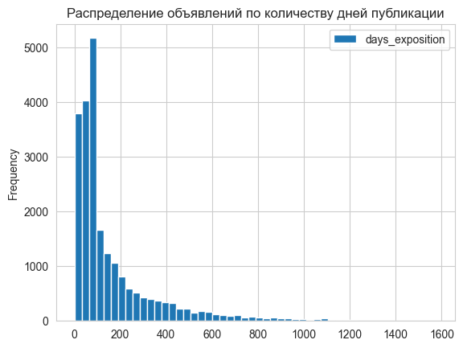

```python
data.plot(y='days_exposition',
          kind='hist',
          grid=True,
          bins=50,
          title="Распределение объявлений по количеству дней публикации"
         )
data['days_exposition'].describe()
```

[figure not shown]

```python
data.boxplot(column='days_exposition')
plt.title("График размаха 'days_exposition'")
plt.show()
```

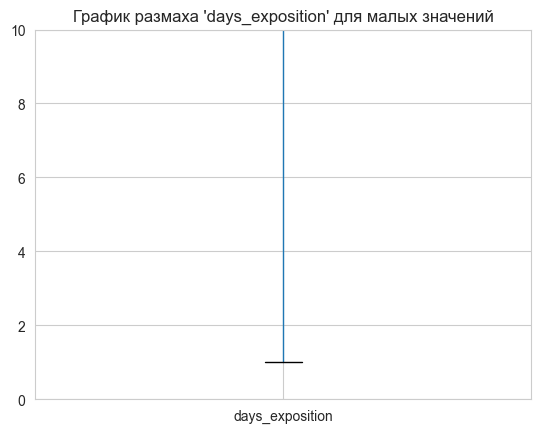

```python
plt.ylim(0, 10)
data.boxplot(column='days_exposition')
plt.title("График размаха 'days_exposition' для малых значений")
plt.show()
```

```python
days_exposition_too_slow = len(data.query('days_exposition > 510')) # Срез данных в которых days_exposition > 510
# Процент этих данных от общего датафрейма
percent_days_exposition_too_slow = days_exposition_too_slow / data['days_exposition'].shape[0] * 100
days_exposition_too_fast = len(data.query('days_exposition <= 1'))
percent_days_exposition_too_fast = days_exposition_too_fast / data['days_exposition'].shape[0] * 100
print(f'Количество объявлений со слишком долгой продажей: {days_exposition_too_slow} -'
        f'это {percent_days_exposition_too_slow:.2f} % от общего количества продаж')
print(f'Количество объявлений со слишком быстрой продажей: {days_exposition_too_fast} -'
        f'это {percent_days_exposition_too_fast:.2f} % от общего количества продаж')
```

```
Количество объявлений со слишком долгой продажей: 1567 -это 6.89 % от общего количества продаж
Количество объявлений со слишком быстрой продажей: 1 -это 0.00 % от общего количества продаж
```

```python
data = data.query('days_exposition <= 510 and days_exposition >= 1')
print("Среднее значение в столбце 'days_exposition': {mean}".format(mean=data['days_exposition'].mean().round(2)))
print("Медианное значение в столбце 'days_exposition': {median}".format(median=data['days_exposition'].median().round(2)))
```

```
Среднее значение в столбце 'days_exposition': 122.61
Медианное значение в столбце 'days_exposition': 95.0
```

### Факторы, которые больше всего влияют на общую (полную) стоимость объекта

**Общая площадь**

```python
data['total_area'].corr(data['last_price']).round(3) # Коэф. корреляции для: общая площадь - цена
```

```
0.628
```

```python
low_area = data.query('total_area <= 200')
low_area['total_area'].corr(low_area['last_price']).round(3) # Коэф. корреляции для: общая площадь (< 200) - цена
```

```
0.726
```

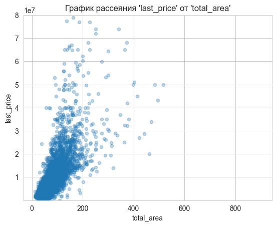

```python
data.plot.scatter(x='total_area', y='last_price', ylim=(10000,80000000), alpha=0.3)
plt.title("График рассеяния 'last_price' от 'total_area'")
plt.show()
```

На графике видна практически линейная зависимоть площади недвижимости от ее стоимоти для объектов с небольшой площадью (до 200 $м^2$), для больших площадей эта зависимость уменьшается, но также является определяющим. Это доказывает значение коэф. корреляции Пирсона, близкому к единице - для малых площадей 0.726, - для всех площадей 0.628.

**Жилая площадь**

```python
data['living_area'].corr(data['last_price']).round(3)
```

```
0.521
```

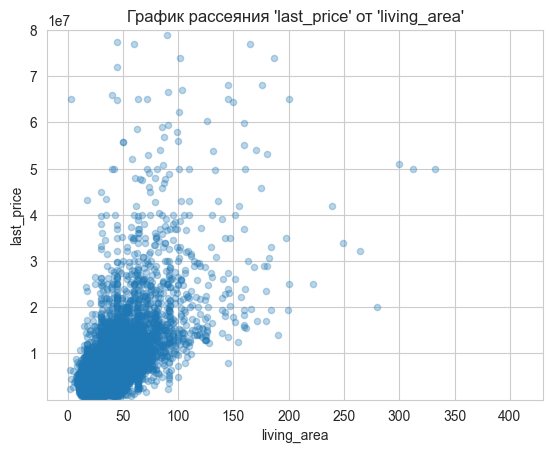

```python
data.plot.scatter(x='living_area', y='last_price', ylim=(10000,80000000), alpha=0.3)
plt.title("График рассеяния 'last_price' от 'living_area'")
plt.show()
```

На графике показано взаимоотношение жилой площади от ее стоимости. Коэф. корреляции Пирсона равен 0.521, это говорит о том, что при увеличении жилой площади увеличивается и ее цена, зависимость менее выраженная по сравнению с общей площадью.

**Площадь кухни**

```python
data['kitchen_area'].corr(data['last_price']).round(3)
```

```
0.394
```

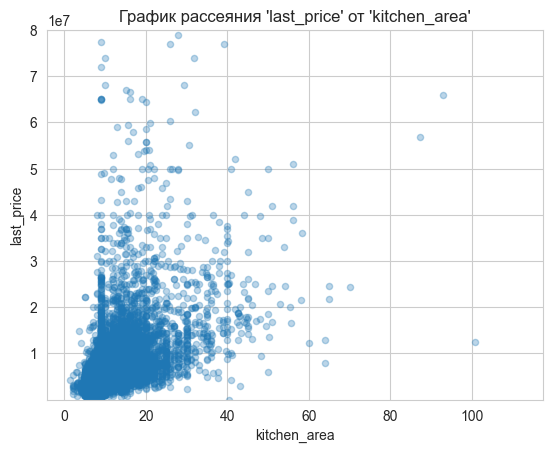

```python
data.plot.scatter(x='kitchen_area', y='last_price', ylim=(10000,80000000), alpha=0.3)
plt.title("График рассеяния 'last_price' от 'kitchen_area'")
plt.show()
```

Коэф. корреляции Пирсона равен 0.394 - это свидетельствует о средней положительной корреляции.

**Количество комнат**

| rooms | mean | count | median |
| --- | --- | --- | --- |
| 0 | 2.872827e+06 | 181 | 2700000.0 |
| 1 | 3.797476e+06 | 7450 | 3599000.0 |
| 2 | 5.399465e+06 | 7234 | 4700000.0 |
| 3 | 7.718058e+06 | 5097 | 6000000.0 |
| 4 | 1.224015e+07 | 918 | 8358500.0 |
| 5 | 2.135657e+07 | 203 | 13000000.0 |
| 6 | 2.766606e+07 | 62 | 18875000.0 |
| 10 | 1.925000e+07 | 2 | 19250000.0 |
| 7 | 5.827115e+07 | 26 | 22095000.0 |
| 9 | 3.488841e+07 | 7 | 23500000.0 |
| 14 | 2.682950e+07 | 2 | 26829500.0 |
| 19 | 3.225000e+07 | 1 | 32250000.0 |
| 8 | 5.863800e+07 | 5 | 36900000.0 |
| 12 | 4.200000e+08 | 1 | 420000000.0 |

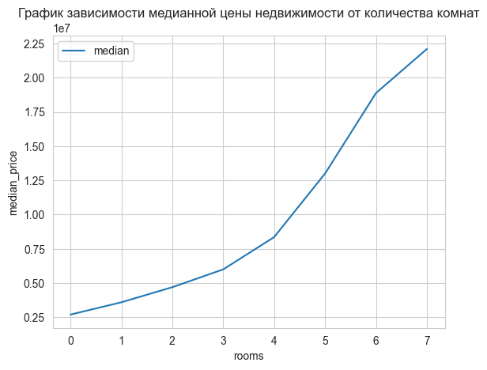

```python
# Создаем сводную таблицу для цены и количества комнат
pivot_table_rooms = data.pivot_table(
    index = 'rooms', values = 'last_price', aggfunc = ['mean', 'count', 'median']
)
pivot_table_rooms.columns = ['mean', 'count', 'median'] # Переименнование столбцов
display(pivot_table_rooms.sort_values(by='median'))
pivot_table_rooms.query('count > 10').plot(y='median') # График зависимости медианной цены от количества комнат
plt.title("График зависимости медианной цены недвижимости от количества комнат")
plt.ylabel("median_price")
plt.show()
```

Цена за объект недвижимости растет с увеличением количества комнат.

```python
data['rooms'].corr(data['last_price']).round(3)
```

```
0.342
```

Коэф. корреляции Пирсона равен 0.342 - это свидетельствует о средней положительной корреляции. Это говорит о слабой прямой зависимости цены недвижимости от количества комнат.

**Тип этажа, на котором расположена квартира**

| floor_type | mean | count | median |
| --- | --- | --- | --- |
| первый | 4.551152e+06 | 2602 | 3800000.0 |
| последний | 6.513048e+06 | 2921 | 4200000.0 |
| другой | 6.142420e+06 | 15666 | 4700000.0 |

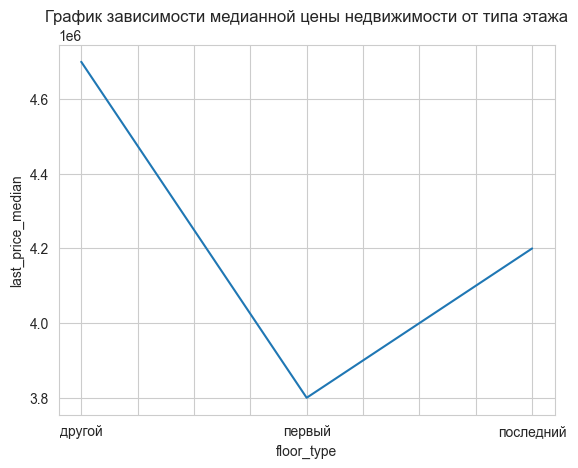

```python
# Создаем сводную таблицу для цены и количества комнат
pivot_table_floor_type = data.pivot_table(
    index = 'floor_type', values = 'last_price', aggfunc = ['mean', 'count', 'median']
)
pivot_table_floor_type.columns = ['mean', 'count', 'median'] # Переименнование столбцов
display(pivot_table_floor_type.sort_values(by='median'))
pivot_table_floor_type.plot(
    y='median', ylabel='last_price_median', legend=None
) # График зависимости медианной цены от количества комнат
plt.title("График зависимости медианной цены недвижимости от типа этажа")
plt.show()
```

```python
data['floor'].corr(data['last_price'])
```

```
0.051372818700597414
```

Из графика зависимоти медианной цены от типа этажа видно, что медианная цена на первые этажи здания самая низкая - это связано с расположенной комерцией на нижних этажах, из которой в квартиру могут заползать насекомые, повышенным акустическим шумом и множеством других факторов. Люди также хуже оценивают последние этажи здания из-за вероятности протечки крыши и тяжелым попаданием в квартиру при отключенном лифте.  
Коэффициент корреляции Пирсона равный 0.05, говорит об отсутствии прямой зависимоти цены объекта от этажа на котором этот объект находится, если он не находится на первом или последнем этаже.

**Дата размещения (день недели, месяц, год)**

**Цена - день недели**

|  | mean | count | median |
| --- | --- | --- | --- |
| Понедельник | 5.891044e+06 | 3240 | 4550000.0 |
| Вторник | 5.848152e+06 | 3731 | 4600000.0 |
| Среда | 6.113018e+06 | 3524 | 4550000.0 |
| Четверг | 5.988161e+06 | 3779 | 4500000.0 |
| Пятница | 5.870467e+06 | 3628 | 4500000.0 |
| Суббота | 6.672500e+06 | 1753 | 4500000.0 |
| Воскресенье | 5.880669e+06 | 1534 | 4500000.0 |

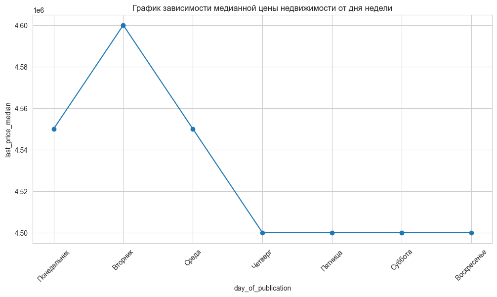

```python
# Создание сводной таблицы для анализа last_price по day_of_publication
pivot_table_day = data.pivot_table(
    index = 'day_of_publication', values = 'last_price', aggfunc = ['mean', 'count', 'median'])

# Переименование столбцов для облегчения восприятия
pivot_table_day.columns = ['mean', 'count', 'median']

# Список дней в правильном порядке
day_order = ['Понедельник', 'Вторник', 'Среда', 'Четверг', 'Пятница', 'Суббота', 'Воскресенье']

# Преобразуем индексы сводной таблицы в категориальные данные с указанием порядка
pivot_table_day.index = pd.Categorical(pivot_table_day.index, categories=day_order, ordered=True)

# Сортируем сводную таблицу по индексам
pivot_table_sorted = pivot_table_day.sort_index()

display(pivot_table_sorted)

# Извлечение индексов в список
index_list = pivot_table_sorted.index.tolist()

# Построение медианного значения Last_price по месяцам
pivot_table_sorted.plot(
    y='median',
    ylabel='last_price_median',
    legend=None,
    xlabel='day_of_publication',
    kind='line',
    marker='o',
    grid=True,
    figsize=(12, 6)
)
plt.xticks(range(len(index_list)), index_list, rotation=45)
plt.title("График зависимости медианной цены недвижимости от дня недели")
plt.show()
```

Четкой взаимосвязи между днем недели и ценой объекта недвижимости не наблюдается, это доказывает малое значение дисперсии = $4*10^4$, которое на два порядка, чем рассматриваемые значения.  
В выходные дни люди реже публикуют объявления, чем в будние

**Цена - месяц**

|  | mean | count | median |
| --- | --- | --- | --- |
| Январь | 6.105459e+06 | 1341 | 4500000.0 |
| Февраль | 6.111705e+06 | 2408 | 4585000.0 |
| Март | 6.002470e+06 | 2289 | 4550000.0 |
| Апрель | 5.883147e+06 | 2150 | 4700000.0 |
| Май | 6.014685e+06 | 1087 | 4410000.0 |
| Июнь | 5.784364e+06 | 1541 | 4300000.0 |
| Июль | 5.786247e+06 | 1495 | 4500000.0 |
| Август | 5.859307e+06 | 1596 | 4500000.0 |
| Сентябрь | 6.513975e+06 | 1781 | 4550000.0 |
| Октябрь | 5.781729e+06 | 1937 | 4500000.0 |
| Ноябрь | 6.028975e+06 | 2156 | 4600000.0 |
| Декабрь | 6.071308e+06 | 1408 | 4510000.0 |

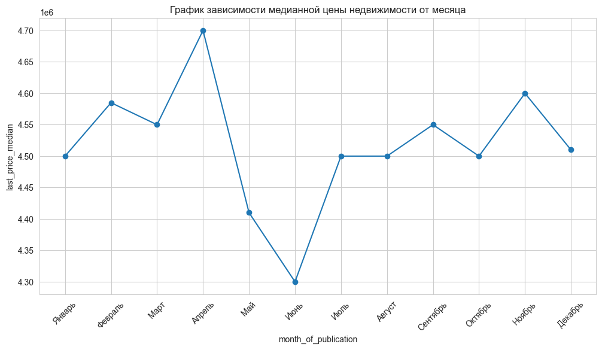

```python
# Создание сводной таблицы для анализа last_price по month_of_publication
pivot_table_month = data.pivot_table(
    index = 'month_of_publication', values = 'last_price', aggfunc = ['mean', 'count', 'median'])

# Переименование столбцов для облегчения восприятия
pivot_table_month.columns = ['mean', 'count', 'median']

# Список месяцев в правильном порядке
month_order = ['Январь', 'Февраль', 'Март', 'Апрель', 'Май', 'Июнь', 'Июль',
               'Август', 'Сентябрь', 'Октябрь', 'Ноябрь', 'Декабрь']

# Преобразуем индексы сводной таблицы в категориальные данные с указанием порядка
pivot_table_month.index = pd.Categorical(pivot_table_month.index, categories=month_order, ordered=True)

# Сортируем сводную таблицу по индексам
pivot_table_sorted = pivot_table_month.sort_index()

display(pivot_table_sorted)

# Извлечение индексов в список
index_list = pivot_table_sorted.index.tolist()

# Построение медианного значения Last_price по месяцам
pivot_table_sorted.plot(
    y='median',
    ylabel='last_price_median',
    legend=None,
    xlabel='month_of_publication',
    kind='line',
    marker='o',
    grid=True,
    figsize=(12, 6)
)
plt.xticks(range(len(index_list)), index_list, rotation=45)
plt.title("График зависимости медианной цены недвижимости от месяца")
plt.show()
```

**Цена - год публикации**

| year_of_publication | mean | count | median |
| --- | --- | --- | --- |
| 2014 | 1.521024e+07 | 17 | 17250000.0 |
| 2015 | 7.517943e+06 | 507 | 4950000.0 |
| 2016 | 6.479734e+06 | 2080 | 4435000.0 |
| 2017 | 6.028195e+06 | 7581 | 4400000.0 |
| 2018 | 5.629006e+06 | 8228 | 4500000.0 |
| 2019 | 6.315072e+06 | 2776 | 4999000.0 |

```
Коэф. корреляции Пирсона: -0.024
```

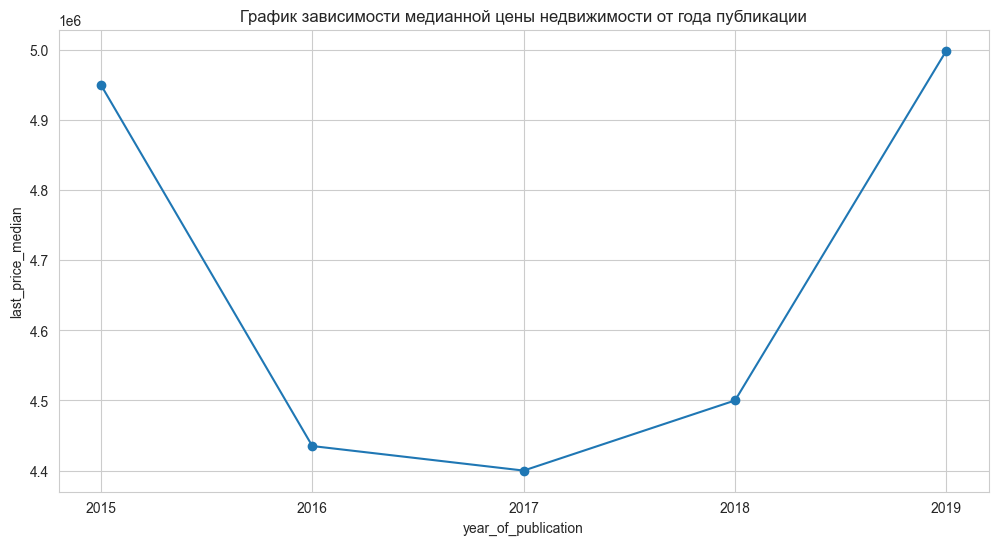

```python
# Создание сводной таблицы для анализа last_price по year_of_publication
pivot_table_year = data.pivot_table(
    index = 'year_of_publication', values = 'last_price', aggfunc = ['mean', 'count', 'median'])

# Переименование столбцов для облегчения восприятия
pivot_table_year.columns = ['mean', 'count', 'median']

# Вывод на экран сводной таблицы
display(pivot_table_year.sort_values(by='year_of_publication'))

# Построение медианного значения Last_price по годам с учетом выбросов
pivot_table_year.query(
    'count > 20').sort_values(by='year_of_publication').plot(
    y='median',
    ylabel='last_price_median',
    legend=None,
    xlabel='year_of_publication',
    kind='line',
    marker='o',
    grid=True,
    figsize=(12, 6)
)

# Извлечение индексов в список
index_list = pivot_table_year.index.tolist()

# Обозначение для оси Х без 2014 года
plt.xticks(index_list[1:])
plt.title("График зависимости медианной цены недвижимости от года публикации")
# Коэф. корреляции между ценой и годом публикации
print('Коэф. корреляции Пирсона: {0}'.format(data['year_of_publication'].corr(data['last_price']).round(3)))
```

На данном графике видно, что в 2016, 2017 и 2018 году цены на квартиры были гораздо ниже, чем в 2015 или в 2019 году.  
Корреляция между показателями "цена" и "год" близка к 0, что говорит об отсутствии линейной зависимости.

### Средняя цена одного квадратного метра в 10 населённых пунктах с наибольшим числом объявлений

| locality_name | count | mean |
| --- | --- | --- |
| Санкт-Петербург | 13844 | 112649 |
| Пушкин | 329 | 102455 |
| деревня Кудрово | 268 | 92671 |
| поселок Парголово | 313 | 89891 |
| поселок Мурино | 519 | 85842 |
| поселок Шушары | 418 | 78465 |
| Колпино | 322 | 75357 |
| Гатчина | 281 | 68955 |
| Всеволожск | 363 | 68642 |
| Выборг | 213 | 57911 |

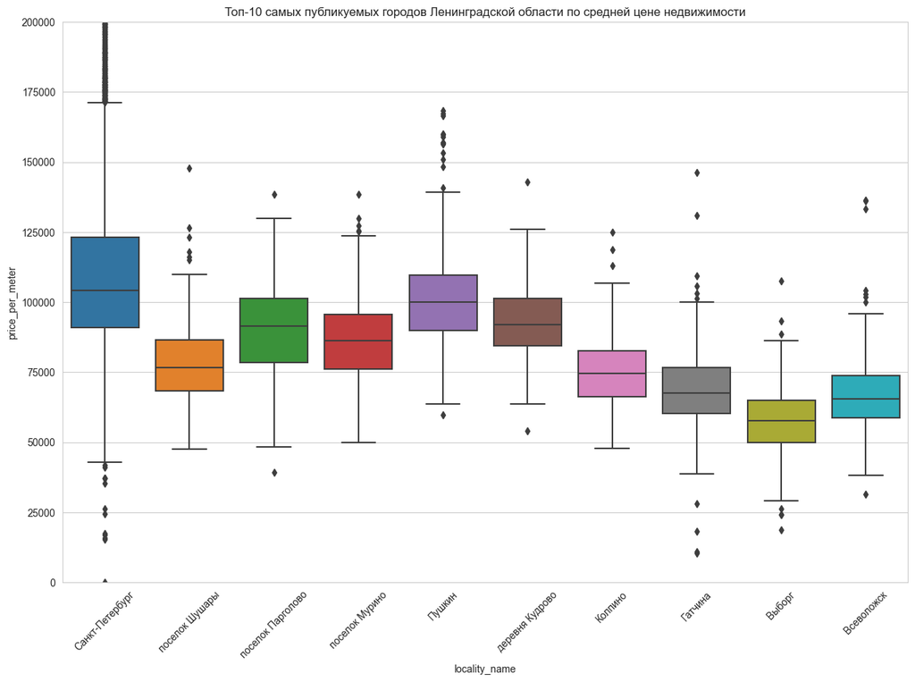

```python
# Создаем сводную таблицу, где индексом является название населённого пункта (locality_name),
# а значения — это средняя цена за квадратный метр (price_per_meter).
# Функции агрегации: count — для подсчета количества записей, mean — для вычисления средней цены.
pivot_table_city = data.pivot_table(
    index = 'locality_name',
    values = 'price_per_meter',
    aggfunc = ['count', 'mean'])

# Переименовываем столбцы сводной таблицы в 'count' (количество) и 'mean' (средняя цена).
pivot_table_city.columns = ['count', 'mean']

# Сортируем сводную таблицу по количеству записей в убывающем порядке
# и оставляем только 10 населённых пунктов с наибольшим количеством данных.
pivot_table_city_top10 = pivot_table_city.sort_values(by='count', ascending=False).head(10)

# Округляем среднюю цену до целого числа и преобразуем её тип к целому числу (int) для лучшего отображения.
pivot_table_city_top10['mean'] = pivot_table_city_top10['mean'].round(0).astype('int')

# Отображаем сводную таблицу, отсортированную по средней цене в убывающем порядке.
display(pivot_table_city_top10.sort_values(by='mean', ascending=False))

# Отбираем данные из исходного DataFrame только по тем населённым пунктам, которые входят в топ-10 по количеству записей.
data2 = data.query('locality_name in @pivot_table_city_top10.index')
f, ax = plt.subplots(figsize=(15, 10))

# Строим коробчатую диаграмму (boxplot) для отображения распределения цен за квадратный метр для каждого
fig = sns.boxplot(x='locality_name', y='price_per_meter', data=data2)

# Устанавливаем границы по оси Y: от 0 до 200000 для цены за квадратный метр.
fig.axis(ymin=0, ymax=200000)

fig.set_title("Топ-10 самых публикуемых городов Ленинградской области по средней цене недвижимости")

# Поворачиваем подписи на оси X (названия населённого пункта) на 45 градусов для лучшей читаемости.
plt.xticks(rotation=45)

plt.show()
```

```python
display(HTML('Cамые дешевые объекты недвижимости - <b>{0}</b>'.format(
    pivot_table_city[pivot_table_city['mean'] == pivot_table_city['mean'].min()].index[0]
)))
display(HTML('Cамые дорогие объекты недвижимости - <b>{0}</b>'.format(
    pivot_table_city[pivot_table_city['mean'] == pivot_table_city['mean'].max()].index[0]
)))
```

Cамые дешевые объекты недвижимости - **деревня Старополье**

Cамые дорогие объекты недвижимости - **поселок Лисий Нос**

### Средняя стоимость квартиры в Санкт-Петербурге на разном удалении от центра

```python
table_peterburg = data.query("locality_name == 'Санкт-Петербург'").pivot_table(
    index='city_centers_nearest_km',
    values='last_price',
    aggfunc=['count', 'mean', 'median']
)
table_peterburg.columns = ['count', 'mean', 'median']
table_peterburg
```

| city_centers_nearest_km | count | mean | median |
| --- | --- | --- | --- |
| 0.0 | 13 | 4.272650e+07 | 30600000.0 |
| 1.0 | 111 | 1.760097e+07 | 10500000.0 |
| 2.0 | 195 | 1.702602e+07 | 9600000.0 |
| 3.0 | 227 | 1.033398e+07 | 8200000.0 |
| 4.0 | 482 | 1.307801e+07 | 8500000.0 |
| 5.0 | 649 | 1.286047e+07 | 8993202.0 |
| 6.0 | 491 | 1.289443e+07 | 8100000.0 |
| 7.0 | 368 | 1.255570e+07 | 7300000.0 |
| 8.0 | 506 | 9.750832e+06 | 7000000.0 |
| 9.0 | 532 | 6.712463e+06 | 5245000.0 |
| 10.0 | 671 | 6.365599e+06 | 4990000.0 |
| 11.0 | 1073 | 6.056288e+06 | 5000000.0 |
| 12.0 | 1558 | 5.985439e+06 | 5000000.0 |
| 13.0 | 1370 | 6.065390e+06 | 5200000.0 |
| 14.0 | 1200 | 5.608956e+06 | 4850000.0 |
| 15.0 | 1481 | 5.857951e+06 | 4900000.0 |
| 16.0 | 1199 | 5.350780e+06 | 4750000.0 |
| 17.0 | 791 | 5.266741e+06 | 4500000.0 |
| 18.0 | 244 | 5.100753e+06 | 4295000.0 |
| 19.0 | 148 | 5.017439e+06 | 4500000.0 |
| 20.0 | 46 | 6.002647e+06 | 5625000.0 |
| 21.0 | 110 | 5.464380e+06 | 5294738.0 |
| 22.0 | 192 | 5.449723e+06 | 4925000.0 |
| 23.0 | 83 | 5.001651e+06 | 4590000.0 |
| 24.0 | 25 | 3.835887e+06 | 3350000.0 |
| 25.0 | 25 | 4.088954e+06 | 3900000.0 |
| 26.0 | 43 | 4.014287e+06 | 3355000.0 |
| 27.0 | 2 | 8.300000e+06 | 8300000.0 |
| 28.0 | 7 | 5.026429e+06 | 4990000.0 |
| 29.0 | 2 | 3.650000e+06 | 3650000.0 |

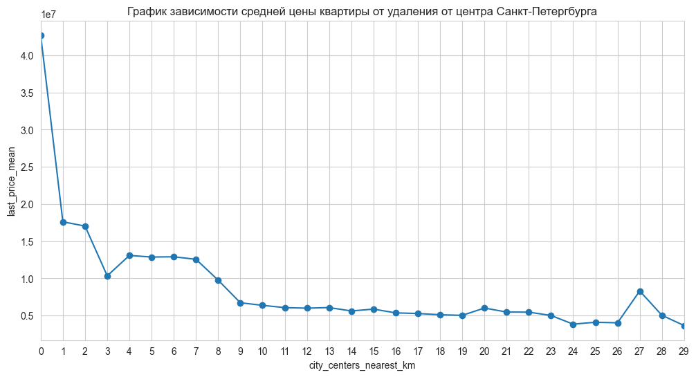

```python
table_peterburg.plot(
    y='mean',
    ylabel='last_price_mean',
    legend=None,
    xlabel='city_centers_nearest_km',
    kind='line',
    marker='o',
    grid=True,
    figsize=(12, 6)
)
plt.xlim(0, 29)
plt.title("График зависимости средней цены квартиры от удаления от центра Санкт-Петергбурга")

# Извлечение индексов в список
index_list = table_peterburg.index.tolist()

# Обозначение для оси Х без 2014 года
plt.xticks(index_list)

plt.show()
```

Средняя цена квартиры в непосредственной близости к центру выше, чем в отдалениии, далее эта зависимость пропадает. Центром Санкт-Петергбурга можно считать квартиры, находящиеся в радиусе до 9 км. График зависимости средней цены квартиры от удаления от центра Санкт-Петергбурга имеет форму Пуассона.

## Общий вывод

В данной работе проводилось исследование объявлений о продаже квартир, в результате которого было выполнено:

- получена первоначальная информация о данных;
- приведены названия всех столбцов к формату snake_case;
- найдены, изучены и заполнены пропуски в датафрейме (там где это возможно);
- информация в датафрейме была приведена к нужному типу данных;
- найдены и удалены явные и неяные дубликаты;
- найдены и обработаны аномалии в данных (например: минимальное значение потолка 1 метр, а максимальное 100 метров);
- добавлены новые столбы в датафрейм (цена за 1 кв. метр; день, месяц и год публикации; тип этажа квартиры; расстояние до центра города в километрах)

Найдено **среднее** время продажи квартиры - 123 дня и **медианное** - 95 дней. Отличие в данных вызвано выбросами - объявления которые находились в публикации более 510 дней, вероятная причина наличия таких объявлений - пользователь забывал снять данные объявления с сайта после продажи квартиры.

Из анализа объявлений о продаже квартир были определены факторы наиболее влияющие на её цену - **общая и жилая площадь квартиры**, меньше на стоимость при продаже квартиры влияли количество комнат в квартире и площадь ее кухни. День, месяц и год продажи квартиры не влияли на её конечную стоимость. Хотя в 2015 и 2019 годах цена продажи выше, чем в 2016-2018 г., но прямой зависимости цены квартиры и года продажи не было выявлено, вероятно на цену квартиры влияли другие факторы - например импотечная ставка.

Были найдены населенные пункты с самым дорогим и самым дешевым жильем ими оказались **поселок Лисий Нос** и **деревня Старополье**.

**Чек-лист готовности проекта**

Поставьте 'x' в выполненных пунктах. Далее нажмите Shift+Enter.

- Файл с данными открыт.
- Файл с данными изучен: выведены первые строки, использован метод `info()`, построены гистограммы.
- Найдены пропущенные значения.
- Пропущенные значения заполнены там, где это возможно.
- Объяснено, какие пропущенные значения обнаружены.
- В каждом столбце установлен корректный тип данных.
- Объяснено, в каких столбцах изменён тип данных и почему.
- Устранены неявные дубликаты в названиях населённых пунктов.
- Обработаны редкие и выбивающиеся значения (аномалии).
- В таблицу добавлены новые параметры: – цена одного квадратного метра; – день публикации объявления (0 - понедельник, 1 - вторник и т. д.); – месяц публикации объявления; – год публикации объявления; – тип этажа квартиры (значения — «первый», «последний», «другой»); – расстояние до центра города в километрах.
- Изучены и описаны параметры: - общая площадь; - жилая площадь; - площадь кухни; - цена объекта; - количество комнат; - высота потолков; - общее количество этажей в доме; - расстояние до центра города в метрах; - расстояние до ближайшего парка.
- Выполнено задание «Изучите, как быстро продавались квартиры (столбец `days_exposition`)»:
  - построена гистограмма;
  - рассчитаны среднее и медиана;
  - описано, сколько обычно занимает продажа и указано, какие продажи можно считать быстрыми, а какие — необычно долгими.
- Выполнено задание «Определите факторы, которые больше всего влияют на общую (полную) стоимость объекта». Построены графики, которые показывают зависимость цены от параметров: - общая площадь; - жилая площадь; - площадь кухни; - количество комнат; - тип этажа, на котором расположена квартира (первый, последний, другой); - дата размещения (день недели, месяц, год).
- Выполнено задание «Посчитайте среднюю цену одного квадратного метра в 10 населённых пунктах с наибольшим числом объявлений»:
  - выделены населённые пункты с самой высокой и низкой стоимостью квадратного метра.
- Выполнено задание «Выделите квартиры в Санкт-Петербурге с помощью столбца `locality_name` и вычислите их среднюю стоимость на разном удалении от центра»:
  - учтён каждый километр расстояния, известны средние цены квартир в одном километре от центра, в двух и так далее;
  - описано, как стоимость объекта зависит от расстояния до центра города;
  - построен график изменения средней цены для каждого километра от центра Петербурга.
- На каждом этапе сделаны промежуточные выводы.
- В конце проекта сделан общий вывод.